# Taller 1 — Comparador de precios: Afeitado y depilación

Minería de Datos (2016325) · Universidad Nacional de Colombia

Autor/a

Inti Abraham Olaya Quinchia (1000240392)

# 1. Introducción

Categoría **Afeitado y depilación** (cuchillas, máquinas de afeitar, espumas, geles, ceras, cremas depilatorias y productos para después del afeitado). Se compara el precio de al menos ocho presentaciones presentes en **tres comercios en línea de Colombia**, elegidos entre los candidatos consultados (La Rebaja, Locatel, Éxito, Olímpica, Jumbo y Carulla) como los tres con mayor cobertura de productos comunes con precio en una misma ejecución,, para identificar dónde conviene comprar y qué tamaño tiene el menor precio por unidad de contenido. Lenguaje: **Python**. Los precios corresponden al momento de captura y no son permanentes.

# 2. Fuentes y scraping

| Comercio | Técnica | Servicio consultado |
| --- | --- | --- |
| Los seis candidatos (todos VTEX) | Peticiones HTTP directas (`requests`) a los servicios JSON de VTEX que usa el propio sitio | `/api/catalog_system/pub/category/tree/3` (descubre las categorías equivalentes) y `/api/catalog_system/pub/products/search?fq=C:/ruta/&_from=&_to=` (50 por página) |

- **Equivalencia de categorías:** se recorre el árbol y se toman los nodos cuyo nombre contiene *afeit, depil, rasur, cuchilla, maquinilla, after shave*; quedan registrados en `categorias_sitio`.
- **Exclusiones:** `RE_EXCLUIR` descarta productos ajenos a la delimitación (toallas higiénicas, desodorantes, etc.) y guarda el motivo en `anuncios.motivo_exclusion`.
- **Completitud:** el encabezado `resources: a-b/TOTAL` da el total del sitio; se compara con los productos obtenidos (`ejecuciones.n_productos` vs `n_esperado_sitio`) y el estado queda *completa* o *parcial*.
- **Buenas prácticas:** pausa de 1 s entre peticiones, reintentos con espera, *User-Agent* identificado. Revisar `robots.txt` de cada sitio antes de ejecutar en vivo.
- **Copias crudas:** `raw/<comercio>/<AAAA-MM-DD>/*.json.gz`; el modo sin conexión reprocesa esas copias.
- **Cumplimiento (`robots.txt`):** se guarda el `robots.txt` de cada comercio en `raw/` y se verifica con `urllib.robotparser` que las dos rutas consultadas estén permitidas:

**Código**

```python
pd.DataFrame(sc.verificar_robots("online" if ONLINE else "offline"))
```

|  | comercio | arbol_categorias_permitido | busqueda_productos_permitida |
| --- | --- | --- | --- |
| 0 | La Rebaja | True | True |
| 1 | Locatel | True | True |
| 2 | Olímpica | True | True |
| 3 | Jumbo | True | True |
| 4 | Carulla | True | True |
| 5 | Éxito | True | True |

- **Términos de uso:** solo se consultan servicios públicos de catálogo, sin autenticación, a baja frecuencia y con fines académicos; no se redistribuyen los datos.

**Código**

```python
resumen = sc.ejecutar_recoleccion_completa("online" if ONLINE else "offline")
pd.DataFrame(resumen).T
```

```
[La Rebaja] completa: 75 registros, 0 observaciones nuevas
[Locatel] completa: 150 registros, 0 observaciones nuevas
[Éxito] parcial: 5019 registros, 0 observaciones nuevas categorías incompletas: ['Máquinas de afeitar eléctricas: 3171/3659']
[Olímpica] completa: 89 registros, 0 observaciones nuevas
[Jumbo] completa: 204 registros, 0 observaciones nuevas
[Carulla] parcial: 4249 registros, 0 observaciones nuevas categorías incompletas: ['Afeitadoras: 2590/3022']
Comercios en el análisis: ['Jumbo', 'Locatel', 'Éxito']. Productos comparables: 49 (147 observaciones).
CUMPLE el mínimo (>=8 productos x 3 comercios).
```

|  | estado | registros | nuevos | detalle |
| --- | --- | --- | --- | --- |
| La Rebaja | completa | 75 | 0 | None |
| Locatel | completa | 150 | 0 | None |
| Éxito | parcial | 5019 | 0 | categorías incompletas: ['Máquinas de afeitar eléctricas... |
| Olímpica | completa | 89 | 0 | None |
| Jumbo | completa | 204 | 0 | None |
| Carulla | parcial | 4249 | 0 | categorías incompletas: ['Afeitadoras: 2590/3022'] |

# 3. Preparación

`scraper.py` estandariza marca (`marca_estandar`), nombre (`nombre_estandar`, `nombre_base`), subcategoría y contenido (`contenido_total` en mL, g, mg o unidad; multipaquetes = contenido × cantidad). El texto original no se modifica. **Correspondencia:** misma presentación = mismo EAN; si falta, misma marca + `nombre_base` + contenido + unidad. `comparable = 1` solo si el producto tiene precio en los tres comercios en la misma corrida. Precios ausentes o agotados quedan en `NULL` (nunca 0).

# 4. Base SQLite

Tablas: `comercios`, `ejecuciones`, `categorias_sitio`, `productos` (id común), `anuncios` (texto original), `observaciones` (precio por fecha, `UNIQUE(anuncio_id, fecha_consulta)`) y la vista `v_obs`.

**Código**

```python
con = sc.conectar()
def q(sql, p=()):
    return pd.read_sql_query(sql, con, params=p)
CORRIDA = con.execute("SELECT corrida_id FROM ejecuciones WHERE estado!='fallida' ORDER BY id DESC LIMIT 1").fetchone()[0]
print("Corrida analizada:", CORRIDA)
q("SELECT corrida_id, comercio, inicio, modo, n_registros, n_productos, n_esperado_sitio, estado FROM ejecuciones")
```

```
Corrida analizada: run-20261024T221730
```

|  | corrida_id | comercio | inicio | modo | n_registros | n_productos | n_esperado_sitio | estado |
| --- | --- | --- | --- | --- | --- | --- | --- | --- |
| 0 | run-20261024T221730 | La Rebaja | 2026-10-24T22:17:30-05:00 | online | 75 | 75 | 75.0 | completa |
| 1 | run-20261024T221730 | Locatel | 2026-10-24T22:17:42-05:00 | online | 150 | 150 | 150.0 | completa |
| 2 | run-20261024T221730 | Éxito | 2026-10-24T22:19:51-05:00 | online | 5019 | 5013 | 5503.0 | parcial |
| 3 | run-20261024T221730 | Olímpica | 2026-10-24T22:26:09-05:00 | online | 89 | 89 | 89.0 | completa |
| 4 | run-20261024T221730 | Jumbo | 2026-10-24T22:26:16-05:00 | online | 204 | 204 | 204.0 | completa |
| 5 | run-20261024T221730 | Carulla | 2026-10-24T22:26:31-05:00 | online | 4249 | 4247 | 4679.0 | parcial |
| 6 | run-20261024T223804 | La Rebaja | 2026-10-24T22:38:04-05:00 | offline | 0 | 0 | NaN | fallida |
| 7 | run-20261024T223804 | Locatel | 2026-10-24T22:38:04-05:00 | offline | 0 | 0 | NaN | fallida |
| 8 | run-20261024T223804 | Éxito | 2026-10-24T22:38:04-05:00 | offline | 0 | 0 | NaN | fallida |
| 9 | run-20261024T223804 | Olímpica | 2026-10-24T22:38:04-05:00 | offline | 0 | 0 | NaN | fallida |
| 10 | run-20261024T223804 | Jumbo | 2026-10-24T22:38:04-05:00 | offline | 0 | 0 | NaN | fallida |
| 11 | run-20261024T223804 | Carulla | 2026-10-24T22:38:04-05:00 | offline | 0 | 0 | NaN | fallida |
| 12 | run-20261024T224410 | La Rebaja | 2026-10-24T22:44:10-05:00 | offline | 0 | 0 | NaN | fallida |
| 13 | run-20261024T224410 | Locatel | 2026-10-24T22:44:10-05:00 | offline | 0 | 0 | NaN | fallida |
| 14 | run-20261024T224410 | Éxito | 2026-10-24T22:44:10-05:00 | offline | 0 | 0 | NaN | fallida |
| 15 | run-20261024T224410 | Olímpica | 2026-10-24T22:44:10-05:00 | offline | 0 | 0 | NaN | fallida |
| 16 | run-20261024T224410 | Jumbo | 2026-10-24T22:44:10-05:00 | offline | 0 | 0 | NaN | fallida |
| 17 | run-20261024T224410 | Carulla | 2026-10-24T22:44:10-05:00 | offline | 0 | 0 | NaN | fallida |

**Comercios usados en el análisis** (la terna con más productos comunes con precio en la misma corrida):

**Código**

```python
q("SELECT c.nombre AS comercio_en_el_analisis FROM seleccion s JOIN comercios c ON c.id = s.comercio_id")
```

|  | comercio_en_el_analisis |
| --- | --- |
| 0 | Jumbo |
| 1 | Locatel |
| 2 | Éxito |

**Verificación de completitud** (productos obtenidos vs. total que informa cada sitio, por categoría)

**Código**

```python
q("""SELECT comercio, nombre AS categoria_sitio, total_sitio FROM categorias_sitio WHERE corrida_id=? ORDER BY comercio""", (CORRIDA,))
```

|  | comercio | categoria_sitio | total_sitio |
| --- | --- | --- | --- |
| 0 | Carulla | Afeitada | 669.0 |
| 1 | Carulla | Preparacion Para La Depilación | NaN |
| 2 | Carulla | Depilación | 393.0 |
| 3 | Carulla | Afeitadoras | 3022.0 |
| 4 | Carulla | Depiladoras eléctricas | 595.0 |
| 5 | Jumbo | Depiladoras Eléctricas | 6.0 |
| 6 | Jumbo | Maquinas De Afeitar | 68.0 |
| 7 | Jumbo | Afeitado | 83.0 |
| 8 | Jumbo | Depilación | 47.0 |
| 9 | La Rebaja | DEPILADORES | NaN |
| 10 | La Rebaja | AFEITADA Y DEPILACION | 65.0 |
| 11 | La Rebaja | AFEITADORA Y CORTADORA CABELLO | 1.0 |
| 12 | La Rebaja | DEPILACION | NaN |
| 13 | La Rebaja | AFEITADO | NaN |
| 14 | La Rebaja | PREPARACION PARA LA AFEITADA | 9.0 |
| 15 | Locatel | Depiladoras y afeitadoras | 53.0 |
| 16 | Locatel | Depiladoras y afeitadoras | NaN |
| 17 | Locatel | afeitada | 77.0 |
| 18 | Locatel | Depilación | 20.0 |
| 19 | Olímpica | Afeitadores | 89.0 |
| 20 | Éxito | Máquinas, espumas y cremas para afeitar | 1608.0 |
| 21 | Éxito | Preparacion Afeitada | 76.0 |
| 22 | Éxito | Preparacion Para La Depilacion | NaN |
| 23 | Éxito | Máquinas de afeitar eléctricas | 3659.0 |
| 24 | Éxito | Depiladores y encrespadores | 160.0 |

# 5. Consultas SQL

**P1. Tamaño de la base**

**Código**

```python
q("""SELECT (SELECT COUNT(*) FROM comercios) comercios,
 (SELECT COUNT(*) FROM productos) productos_comunes, (SELECT COUNT(*) FROM anuncios) anuncios,
 (SELECT COUNT(*) FROM observaciones) observaciones""")
```

|  | comercios | productos_comunes | anuncios | observaciones |
| --- | --- | --- | --- | --- |
| 0 | 6 | 5292 | 9786 | 9786 |

**Código**

```python
q("SELECT comercio, COUNT(DISTINCT sku) productos FROM v_obs WHERE corrida_id=? GROUP BY comercio", (CORRIDA,))
```

|  | comercio | productos |
| --- | --- | --- |
| 0 | Carulla | 4249 |
| 1 | Jumbo | 204 |
| 2 | La Rebaja | 75 |
| 3 | Locatel | 150 |
| 4 | Olímpica | 89 |
| 5 | Éxito | 5019 |

**P2. ¿≥ 24 observaciones comparables en una misma ejecución? ¿Repetidos?**

**Código**

```python
q("""SELECT COUNT(*) obs_comparables, COUNT(DISTINCT producto_id) productos, COUNT(DISTINCT comercio) comercios,
 (COUNT(*) >= 24 AND COUNT(DISTINCT comercio) = 3 AND COUNT(DISTINCT producto_id) >= 8) AS cumple_24 FROM v_obs WHERE corrida_id=? AND comparable=1 AND precio_cop IS NOT NULL""", (CORRIDA,))
```

|  | obs_comparables | productos | comercios | cumple_24 |
| --- | --- | --- | --- | --- |
| 0 | 147 | 49 | 3 | 1 |

**Código**

```python
q("""SELECT producto_id, comercio, COUNT(*) n FROM v_obs WHERE corrida_id=? AND comparable=1
 GROUP BY 1,2 HAVING n>1""", (CORRIDA,))
```

|  | producto_id | comercio | n |
| --- | --- | --- | --- |
| 0 | 21255 | Éxito | 2 |

**P3. Mínimo, máximo, promedio y comercio más barato (con empates)**

**Código**

```python
P3 = q("""WITH c AS (SELECT producto_id, nombre_estandar, comercio, precio_cop FROM v_obs
  WHERE corrida_id=? AND comparable=1 AND precio_cop IS NOT NULL),
 s AS (SELECT producto_id, MIN(precio_cop) pmin, MAX(precio_cop) pmax, ROUND(AVG(precio_cop)) prom FROM c GROUP BY 1)
SELECT s.producto_id, (SELECT nombre_estandar FROM c WHERE c.producto_id=s.producto_id LIMIT 1) producto,
 pmin, pmax, prom, (SELECT group_concat(comercio, ' / ') FROM c WHERE c.producto_id=s.producto_id AND c.precio_cop=s.pmin) mas_barato
FROM s ORDER BY producto_id""", (CORRIDA,))
P3
```

|  | producto_id | producto | pmin | pmax | prom | mas_barato |
| --- | --- | --- | --- | --- | --- | --- |
| 0 | 21173 | crema veet depilatoria piel sensible con espatula x100ml | 34000.0 | 35450.0 | 34533.0 | Éxito |
| 1 | 21178 | crema depilatoria veet para pieles sensibles x200ml | 31490.0 | 36000.0 | 33247.0 | Jumbo |
| 2 | 21181 | crema depilatoria veet para pieles normales x200ml | 30700.0 | 32290.0 | 31747.0 | Éxito |
| 3 | 21186 | repuesto cuchilla de afeitar gillette venus ultra comfor... | 19890.0 | 42150.0 | 34530.0 | Jumbo |
| 4 | 21187 | maquina schick quattro mujer sensitive repuesto x2und | 27400.0 | 34990.0 | 32063.0 | Éxito |
| 5 | 21188 | repuestos para maquina de afeitar schick quattro mujer x... | 24650.0 | 26990.0 | 25897.0 | Locatel |
| 6 | 21195 | cuchilla de afeitar gillette venus breeze maquina de afe... | 39500.0 | 44290.0 | 41897.0 | Éxito |
| 7 | 21197 | cuchilla de afeitar con carbon gillette mach 3 carbono x... | 32700.0 | 34500.0 | 33483.0 | Jumbo |
| 8 | 21207 | cuchilla de afeitar gillette venus extra suave 3 uds maq... | 33800.0 | 39450.0 | 35713.0 | Éxito |
| 9 | 21209 | cuchilla de afeitar gillette prestobarba 3, 4 uds maquin... | 30450.0 | 34450.0 | 32400.0 | Jumbo |
| 10 | 21211 | cuchilla de afeitar gillette prestobarba 3 maquina de af... | 28000.0 | 30750.0 | 29550.0 | Jumbo |
| 11 | 21212 | gillette mach 3 cuchilla de afeitar hombre 1 und 2 repue... | 38890.0 | 50600.0 | 44347.0 | Jumbo |
| 12 | 21213 | repuestos cuchilla de afeitar gillette proshield 2 uds r... | 42700.0 | 48750.0 | 44750.0 | Éxito |
| 13 | 21214 | repuestos cuchilla de afeitar gillette proshield 4 und | 89750.0 | 96500.0 | 92813.0 | Locatel |
| 14 | 21215 | maquina de afeitar gillette mach3 aquagrip x1und repuesto | 19890.0 | 30050.0 | 25897.0 | Jumbo |
| 15 | 21221 | repuestos para cuchilla de afeitar gillette mach 3 sensi... | 33690.0 | 35900.0 | 34697.0 | Jumbo |
| 16 | 21226 | espuma de afeitar gillette sensitive piel sensible x155ml | 19090.0 | 20750.0 | 19847.0 | Jumbo |
| 17 | 21235 | bandas depilatorias veet facial piel sensible x16 und | 25870.0 | 27200.0 | 26740.0 | Jumbo |
| 18 | 21236 | repuestos cuchilla de afeitar gillette fusion 5 2und | 35650.0 | 36590.0 | 36247.0 | Locatel |
| 19 | 21237 | maquina para afeitar desechables x2 und schick hydro 5 h... | 25450.0 | 26890.0 | 26230.0 | Locatel |
| 20 | 21240 | repuesto intuition sensitive x 2und | 32100.0 | 33800.0 | 32997.0 | Locatel |
| 21 | 21242 | repuestos para cuchilla de afeitar gillette mach 3 sensi... | 40150.0 | 77600.0 | 63547.0 | Éxito |
| 22 | 21244 | balsamo after shave nivea men sensitive x100ml | 33890.0 | 57500.0 | 47023.0 | Jumbo |
| 23 | 21245 | maquina desechable x2 und xtreme 3 mujer hawaiian tropic | 14950.0 | 15850.0 | 15373.0 | Éxito |
| 24 | 21246 | maquina de afeitar desechable x2 und quattro mujer sensi... | 16575.0 | 21000.0 | 19412.0 | Éxito |
| 25 | 21249 | bandas depilatorias veet piernas cuerpo x12 und | 41750.0 | 44600.0 | 42927.0 | Locatel |
| 26 | 21251 | maquina de afeitar para mujer schick intuition x1 und | 32000.0 | 33800.0 | 33130.0 | Locatel |
| 27 | 21253 | gel para afeitar antibacterial nivea men deep carbon act... | 33890.0 | 53900.0 | 46080.0 | Jumbo |
| 28 | 21254 | repuestos para cuchilla de afeitar gillette mach 3 con 3... | 68190.0 | 81550.0 | 74700.0 | Jumbo |
| 29 | 21255 | afeitadora electrica gillette styler afeitado barba y cu... | 122700.0 | 153700.0 | 133797.0 | Locatel |
| 30 | 21256 | cuchilla de afeitar mujer gillette venus ultra comfort s... | 38190.0 | 38650.0 | 38447.0 | Jumbo |
| 31 | 21257 | maquina de afeitar desechable x2 und schick quattro tita... | 19470.0 | 21000.0 | 19990.0 | Jumbo |
| 32 | 21262 | maquina schick desechable x2und | 14700.0 | 21440.0 | 18947.0 | Éxito |
| 33 | 21264 | cuchillas de afeitar gillette prestobarba 3 carbono con ... | 20550.0 | 22150.0 | 21597.0 | Locatel |
| 34 | 21265 | bandas depilatorias veet axilas bikini x16 und | 39900.0 | 40050.0 | 39983.0 | Locatel |
| 35 | 21267 | repuestos para cuchilla de afeitar gillette mach 3 carbo... | 63150.0 | 67000.0 | 65050.0 | Locatel |
| 36 | 21274 | maquina de afeitar gillette prestobarba3 sensecare desec... | 30990.0 | 38800.0 | 35263.0 | Jumbo |
| 37 | 21275 | maquina gillette mach3 sensitive aloe | 35500.0 | 39590.0 | 38013.0 | Éxito |
| 38 | 21276 | repuesto cuchilla de afeitar gillette venus ultra comfor... | 39300.0 | 39450.0 | 39350.0 | Jumbo / Éxito |
| 39 | 21278 | cuchilla de afeitar hombre gillette fusion 5 1und | 35650.0 | 36500.0 | 35947.0 | Locatel |
| 40 | 21280 | repuestos para cuchilla de afeitar gillette mach 3 sensi... | 48500.0 | 61800.0 | 56963.0 | Éxito |
| 41 | 21281 | cuchilla de afeitar con aloe gillette prestobarba 3 sens... | 20200.0 | 21850.0 | 20813.0 | Locatel |
| 42 | 21293 | repuestos cuchilla de afeitar mujer gillette venus area ... | 41500.0 | 47300.0 | 44697.0 | Locatel |
| 43 | 21294 | cuchilla de afeitar mujer gillette venus intima 2und cuc... | 22090.0 | 22590.0 | 22310.0 | Jumbo |
| 44 | 21295 | cuchilla de afeitar gillette venus area intima maquina a... | 43900.0 | 47300.0 | 45833.0 | Jumbo |
| 45 | 21296 | maquina schick xtreme3 beauty mujer x2 unidades | 14890.0 | 17850.0 | 16347.0 | Jumbo |
| 46 | 21297 | cuchilla de afeitar gillette venus extra suave sensitive... | 28690.0 | 30650.0 | 29397.0 | Jumbo |
| 47 | 21298 | maquina schick depilacion desechable exacta2 x3und | 10400.0 | 10650.0 | 10547.0 | Éxito |
| 48 | 21301 | crema depilatoria veet kit facial x2und x50ml | 29040.0 | 38750.0 | 34593.0 | Locatel |

**P4 y P6. Ahorro en COP y % (ordenado por ahorro porcentual)**

**Código**

```python
P4 = q("""WITH c AS (SELECT producto_id, nombre_estandar, precio_cop FROM v_obs
  WHERE corrida_id=? AND comparable=1 AND precio_cop IS NOT NULL)
SELECT producto_id, MIN(nombre_estandar) producto, MIN(precio_cop) pmin, MAX(precio_cop) pmax,
 MAX(precio_cop)-MIN(precio_cop) ahorro_cop, ROUND(100.0*(MAX(precio_cop)-MIN(precio_cop))/MAX(precio_cop),1) ahorro_pct
FROM c GROUP BY producto_id ORDER BY ahorro_pct DESC""", (CORRIDA,))
P4
```

|  | producto_id | producto | pmin | pmax | ahorro_cop | ahorro_pct |
| --- | --- | --- | --- | --- | --- | --- |
| 0 | 21186 | repuesto cuchilla de afeitar gillette venus ultra comfor... | 19890.0 | 42150.0 | 22260.0 | 52.8 |
| 1 | 21242 | repuesto cuchilla de afeitar mach 3 sensitive 6 und | 40150.0 | 77600.0 | 37450.0 | 48.3 |
| 2 | 21244 | after shave nivea for men pos sensitive 100ml | 33890.0 | 57500.0 | 23610.0 | 41.1 |
| 3 | 21253 | gel de afeitar nivea men deep carbon 200 ml | 33890.0 | 53900.0 | 20010.0 | 37.1 |
| 4 | 21215 | maquina de afeitar gillette mach3 aquagrip repuesto x 2und | 19890.0 | 30050.0 | 10160.0 | 33.8 |
| 5 | 21262 | maquina de afeitar schick quattro 4 you x 2und | 14700.0 | 21440.0 | 6740.0 | 31.4 |
| 6 | 21301 | crema depilatoria veet facial crema post depilatoria 50 ml | 29040.0 | 38750.0 | 9710.0 | 25.1 |
| 7 | 21212 | cuchilla de afeitar mach 3 gillette 2 und | 38890.0 | 50600.0 | 11710.0 | 23.1 |
| 8 | 21187 | maquina de afeitar recargable schick quattro 4 piel deli... | 27400.0 | 34990.0 | 7590.0 | 21.7 |
| 9 | 21280 | repuesto cuchilla de afeitar mach 3 gillette sensitive 4... | 48500.0 | 61800.0 | 13300.0 | 21.5 |
| 10 | 21246 | maquina de afeitar desechable x2 und quattro mujer sensi... | 16575.0 | 21000.0 | 4425.0 | 21.1 |
| 11 | 21255 | afeitadora electrica gillette styler afeitado barba y cu... | 122700.0 | 153700.0 | 31000.0 | 20.2 |
| 12 | 21274 | cuchilla de afeitar prestobarba 3 gillette sensitive 4 und | 30990.0 | 38800.0 | 7810.0 | 20.1 |
| 13 | 21296 | maquina de afeitar schick xtreme 3 beauty x 2und | 14890.0 | 17850.0 | 2960.0 | 16.6 |
| 14 | 21254 | repuesto cuchilla de afeitar mach 3 gillette con 3 hojas... | 68190.0 | 81550.0 | 13360.0 | 16.4 |
| 15 | 21207 | cuchilla de afeitar gillette venus extra suave 3 uds maq... | 33800.0 | 39450.0 | 5650.0 | 14.3 |
| 16 | 21178 | crema depilatoria veet para pieles sensibles x200ml | 31490.0 | 36000.0 | 4510.0 | 12.5 |
| 17 | 21213 | repuesto cuchilla de afeitar fusion gillette proshield 2... | 42700.0 | 48750.0 | 6050.0 | 12.4 |
| 18 | 21293 | repuesto cuchilla de afeitar venus intima 2 und | 41500.0 | 47300.0 | 5800.0 | 12.3 |
| 19 | 21209 | cuchilla de afeitar gillette prestobarba 3, 4 uds maquin... | 30450.0 | 34450.0 | 4000.0 | 11.6 |
| 20 | 21195 | cuchilla de afeitar gillette venus breeze maquina de afe... | 39500.0 | 44290.0 | 4790.0 | 10.8 |
| 21 | 21275 | maquina de afeitar gillette mach3 sensitive 1und 2 repue... | 35500.0 | 39590.0 | 4090.0 | 10.3 |
| 22 | 21211 | cuchilla de afeitar gillette prestobarba 3 maquina de af... | 28000.0 | 30750.0 | 2750.0 | 8.9 |
| 23 | 21188 | repuesto maquina afeitar schick women sensitive x 2 unid... | 24650.0 | 26990.0 | 2340.0 | 8.7 |
| 24 | 21226 | espuma de afeitar gillette sensitive 150 gr | 19090.0 | 20750.0 | 1660.0 | 8.0 |
| 25 | 21281 | cuchilla de afeitar con aloe gillette prestobarba 3 sens... | 20200.0 | 21850.0 | 1650.0 | 7.6 |
| 26 | 21257 | maquina de afeitar desechable x2 und schick quattro tita... | 19470.0 | 21000.0 | 1530.0 | 7.3 |
| 27 | 21295 | cuchilla de afeitar gillette venus area intima maquina a... | 43900.0 | 47300.0 | 3400.0 | 7.2 |
| 28 | 21264 | cuchilla de afeitar gillette prestobarba 3 carbono 2 und | 20550.0 | 22150.0 | 1600.0 | 7.2 |
| 29 | 21214 | repuesto cuchilla de afeitar fusion gillette proshield 4... | 89750.0 | 96500.0 | 6750.0 | 7.0 |
| 30 | 21297 | cuchilla de afeitar gillette venus extra suave sensitive... | 28690.0 | 30650.0 | 1960.0 | 6.4 |
| 31 | 21249 | bandas cera veet piel sensible x 12 | 41750.0 | 44600.0 | 2850.0 | 6.4 |
| 32 | 21221 | repuesto cuchilla de afeitar mach 3 gillette sensitive 2... | 33690.0 | 35900.0 | 2210.0 | 6.2 |
| 33 | 21267 | repuesto cuchilla de afeitar mach 3 carbono 4 und | 63150.0 | 67000.0 | 3850.0 | 5.7 |
| 34 | 21245 | maquina afeitar schick xtreme3 hawaiian tropic x 2und | 14950.0 | 15850.0 | 900.0 | 5.7 |
| 35 | 21237 | maquina afeitar schick hydro 5 hojas x 2und | 25450.0 | 26890.0 | 1440.0 | 5.4 |
| 36 | 21251 | maquina de afeitar para mujer schick intuition x1 und | 32000.0 | 33800.0 | 1800.0 | 5.3 |
| 37 | 21197 | cuchilla de afeitar con carbon gillette mach 3 carbono x... | 32700.0 | 34500.0 | 1800.0 | 5.2 |
| 38 | 21240 | maquina de afeitar schick intuition sensitive repuestos ... | 32100.0 | 33800.0 | 1700.0 | 5.0 |
| 39 | 21235 | bandas cera veet depilacion facial piel sensible x 16 | 25870.0 | 27200.0 | 1330.0 | 4.9 |
| 40 | 21181 | crema depilatoria veet para pieles normales x200ml | 30700.0 | 32290.0 | 1590.0 | 4.9 |
| 41 | 21173 | crema depilatoria axilas y bikini veet x 100ml | 34000.0 | 35450.0 | 1450.0 | 4.1 |
| 42 | 21236 | repuesto cuchilla de afeitar fusion gillette 5 2 und | 35650.0 | 36590.0 | 940.0 | 2.6 |
| 43 | 21298 | maquina afeitar schick exacta 2 delicada x 3und | 10400.0 | 10650.0 | 250.0 | 2.3 |
| 44 | 21278 | cuchilla de afeitar fusion 5 gillette 1 und | 35650.0 | 36500.0 | 850.0 | 2.3 |
| 45 | 21294 | cuchilla de afeitar mujer gillette venus intima 2und cuc... | 22090.0 | 22590.0 | 500.0 | 2.2 |
| 46 | 21256 | cuchilla de afeitar mujer gillette venus ultra comfort s... | 38190.0 | 38650.0 | 460.0 | 1.2 |
| 47 | 21276 | repuesto cuchilla de afeitar gillette venus ultra comfor... | 39300.0 | 39450.0 | 150.0 | 0.4 |
| 48 | 21265 | bandas cera veet axilas y bikini x 16 | 39900.0 | 40050.0 | 150.0 | 0.4 |

**P5. Menor precio por mL/g/mg/unidad entre tamaños del mismo producto** (no se mezclan unidades)

**Código**

```python
P5 = q("""SELECT marca_estandar, nombre_base, unidad_base, comercio, contenido_total, precio_cop,
 ROUND(precio_cop/contenido_total, 2) precio_por_unidad,
 RANK() OVER (PARTITION BY marca_estandar, nombre_base, unidad_base ORDER BY precio_cop/contenido_total) ranking
FROM v_obs WHERE corrida_id=? AND excluido=0 AND precio_cop IS NOT NULL AND contenido_total>0
 AND (marca_estandar, nombre_base, unidad_base) IN (SELECT marca_estandar, nombre_base, unidad_base FROM v_obs
   WHERE corrida_id=? AND excluido=0 AND contenido_total>0 GROUP BY 1,2,3 HAVING COUNT(DISTINCT contenido_total)>1)
ORDER BY marca_estandar, nombre_base, unidad_base, ranking""", (CORRIDA, CORRIDA))
P5.head(30)
```

|  | marca_estandar | nombre_base | unidad_base | comercio | contenido_total | precio_cop | precio_por_unidad | ranking |
| --- | --- | --- | --- | --- | --- | --- | --- | --- |
| 0 | Ampm Plus | afeitar aloe banda lubricante maquina vera | unidad | Éxito | 4.0 | 5260.0 | 1315.00 | 1 |
| 1 | Ampm Plus | afeitar aloe banda lubricante maquina vera | unidad | Carulla | 4.0 | 5600.0 | 1400.00 | 2 |
| 2 | Ampm Plus | afeitar aloe banda lubricante maquina vera | unidad | Éxito | 4.0 | 5790.0 | 1447.50 | 3 |
| 3 | Ampm Plus | afeitar aloe banda lubricante maquina vera | unidad | Carulla | 4.0 | 6120.0 | 1530.00 | 4 |
| 4 | Ampm Plus | afeitar aloe banda lubricante maquina vera | unidad | Éxito | 1.0 | 14050.0 | 14050.00 | 5 |
| 5 | Ampm Plus | afeitar aloe banda lubricante maquina vera | unidad | Éxito | 1.0 | 14400.0 | 14400.00 | 6 |
| 6 | Ampm Plus | afeitar aloe banda lubricante maquina vera | unidad | Carulla | 1.0 | 14850.0 | 14850.00 | 7 |
| 7 | Ampm Plus | afeitar aloe banda maquina vera vitamina | unidad | Carulla | 1.0 | 2300.0 | 2300.00 | 1 |
| 8 | Ampm Plus | afeitar aloe banda maquina vera vitamina | unidad | Éxito | 1.0 | 2370.0 | 2370.00 | 2 |
| 9 | Ampm Plus | afeitar aloe banda maquina vera vitamina | unidad | Carulla | 2.0 | 4990.0 | 2495.00 | 3 |
| 10 | Ampm Plus | afeitar aloe banda maquina vera vitamina | unidad | Carulla | 2.0 | 6500.0 | 3250.00 | 4 |
| 11 | Babaria | afeitar aloe espuma | mL | Jumbo | 300.0 | 25270.0 | 84.23 | 1 |
| 12 | Babaria | afeitar aloe espuma vera | mL | Locatel | 300.0 | 23800.0 | 79.33 | 1 |
| 13 | Babaria | afeitar aloe espuma vera | mL | Éxito | 300.0 | 29000.0 | 96.67 | 2 |
| 14 | Babaria | afeitar aloe espuma vera | mL | Carulla | 300.0 | 29000.0 | 96.67 | 2 |
| 15 | Bell Franz | aloe cera depilatoria miel | g | Éxito | 905.0 | 55500.0 | 61.33 | 1 |
| 16 | Bell Franz | aloe cera depilatoria miel | g | Carulla | 905.0 | 55500.0 | 61.33 | 1 |
| 17 | Bell Franz | aloe cera depilatoria miel | g | Éxito | 500.0 | 37000.0 | 74.00 | 3 |
| 18 | Bell Franz | aloe cera depilatoria miel | g | Carulla | 500.0 | 37000.0 | 74.00 | 3 |
| 19 | Bell Franz | aloe cera depilatoria miel | g | Éxito | 240.0 | 23300.0 | 97.08 | 5 |
| 20 | Bell Franz | aloe cera depilatoria miel | g | Carulla | 240.0 | 23300.0 | 97.08 | 5 |
| 21 | Bell Franz | azuleno cera depilatoria | g | Carulla | 905.0 | 61000.0 | 67.40 | 1 |
| 22 | Bell Franz | azuleno cera depilatoria | g | Éxito | 500.0 | 41000.0 | 82.00 | 2 |
| 23 | Bell Franz | azuleno cera depilatoria | g | Carulla | 500.0 | 41000.0 | 82.00 | 2 |
| 24 | Bell Franz | cera cero chocolate depilatoria suave vello | g | Éxito | 905.0 | 60100.0 | 66.41 | 1 |
| 25 | Bell Franz | cera cero chocolate depilatoria suave vello | g | Éxito | 240.0 | 24000.0 | 100.00 | 2 |
| 26 | Bell Franz | cera cero chocolate depilatoria suave vello | g | Carulla | 240.0 | 24000.0 | 100.00 | 2 |
| 27 | Bell Franz | cera cero depilatoria kiwi suaviza vellos | g | Éxito | 905.0 | 60100.0 | 66.41 | 1 |
| 28 | Bell Franz | cera cero depilatoria kiwi suaviza vellos | g | Éxito | 240.0 | 23300.0 | 97.08 | 2 |
| 29 | Bell Franz | cera depilatoria miel | g | Éxito | 905.0 | 60100.0 | 66.41 | 1 |

**P7. Datos faltantes o inconsistentes**

**Código**

```python
q("""SELECT COUNT(*) observaciones,
 SUM(precio_cop IS NULL) sin_precio, SUM(disponible=0) agotados,
 SUM(marca_estandar IS NULL) sin_marca, SUM(contenido_total IS NULL) sin_contenido,
 SUM(texto_original IS NULL OR texto_original='') sin_texto, SUM(excluido) excluidos
FROM v_obs WHERE corrida_id=?""", (CORRIDA,))
```

|  | observaciones | sin_precio | agotados | sin_marca | sin_contenido | sin_texto | excluidos |
| --- | --- | --- | --- | --- | --- | --- | --- |
| 0 | 9786 | 7720 | 7720 | 0 | 7956 | 0 | 21 |

**P8. Oferta por comercio y completitud de la ficha**

**Código**

```python
q("""SELECT comercio, COUNT(DISTINCT sku) productos, SUM(excluido) excluidos,
 ROUND(100.0*AVG(marca_estandar IS NOT NULL),1) pct_marca,
 ROUND(100.0*AVG(contenido_total IS NOT NULL),1) pct_contenido,
 ROUND(100.0*AVG(LENGTH(texto_original)>60),1) pct_descripcion
FROM v_obs WHERE corrida_id=? GROUP BY comercio""", (CORRIDA,))
```

|  | comercio | productos | excluidos | pct_marca | pct_contenido | pct_descripcion |
| --- | --- | --- | --- | --- | --- | --- |
| 0 | Carulla | 4249 | 9 | 100.0 | 16.5 | 95.1 |
| 1 | Jumbo | 204 | 0 | 100.0 | 60.8 | 99.5 |
| 2 | La Rebaja | 75 | 1 | 100.0 | 78.7 | 98.7 |
| 3 | Locatel | 150 | 1 | 100.0 | 58.7 | 100.0 |
| 4 | Olímpica | 89 | 0 | 100.0 | 1.1 | 100.0 |
| 5 | Éxito | 5019 | 10 | 100.0 | 17.1 | 95.6 |

**Código**

```python
def interpretar():
    if P3.empty:
        return "No hay productos comparables en la corrida analizada."
    top = P4.iloc[0]
    return (f"Se compararon {len(P3)} presentaciones. La mayor diferencia entre comercios está en "
            f"«{top['producto']}»: {top['ahorro_cop']:,.0f} COP ({top['ahorro_pct']}%). "
            f"Ahorro promedio: {P4['ahorro_pct'].mean():.1f}%. No se concluye que un comercio sea globalmente más barato.")
print(interpretar())
```

```
Se compararon 49 presentaciones. La mayor diferencia entre comercios está en «repuesto cuchilla de afeitar gillette venus ultra comfort breeze 2 uds repuesto cuchilla de afeitar gillette venus breeze x2und»: 22,260 COP (52.8%). Ahorro promedio: 13.3%. No se concluye que un comercio sea globalmente m…
```

# 6. Visualizaciones

**Código**

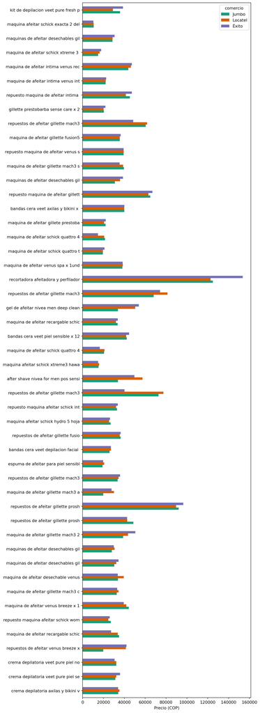

Precio (COP) por comercio de las presentaciones comparables

```python
D = q("SELECT producto_id, nombre_estandar, comercio, precio_cop FROM v_obs WHERE corrida_id=? AND comparable=1 AND precio_cop IS NOT NULL", (CORRIDA,))
if not D.empty:
    W = D.pivot_table(index="producto_id", columns="comercio", values="precio_cop")
    W.index = [D[D.producto_id == i].nombre_estandar.iloc[0][:35] for i in W.index]
    W.plot.barh(figsize=(9, max(4, .5 * len(W))), color=dict(zip(W.columns, ["#1b9e77", "#d95f02", "#7570b3", "#e7298a"])))
    plt.xlabel("Precio (COP)"); plt.tight_layout(); plt.show()
```

La barra más corta de cada producto indica la oferta más económica; las diferencias se leen en COP. *Limitación:* son precios de una sola captura; pueden incluir promociones.

**Código**

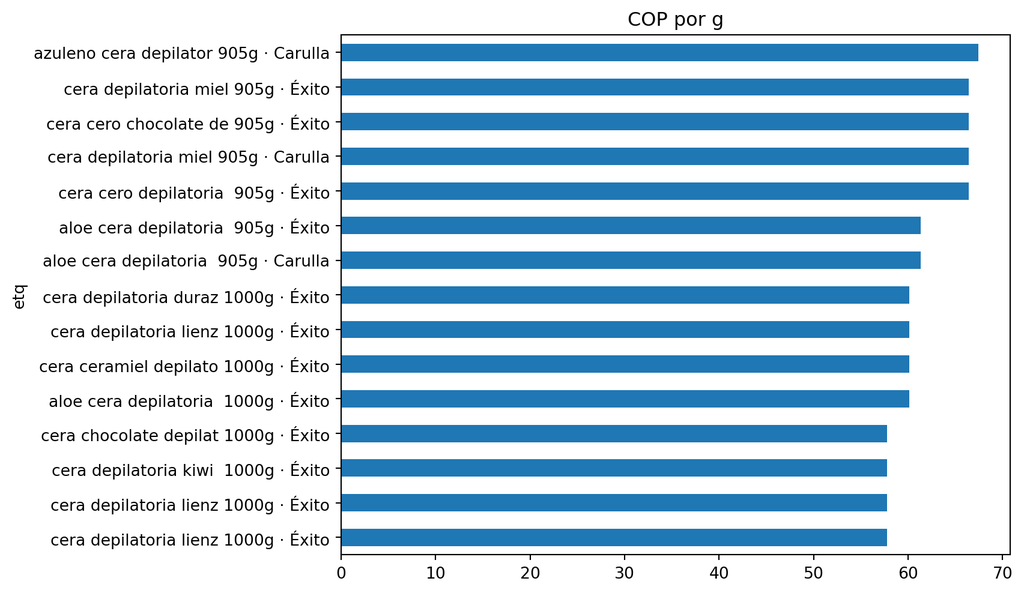

Precio por unidad de contenido (COP/mL, g o unidad) entre tamaños del mismo producto

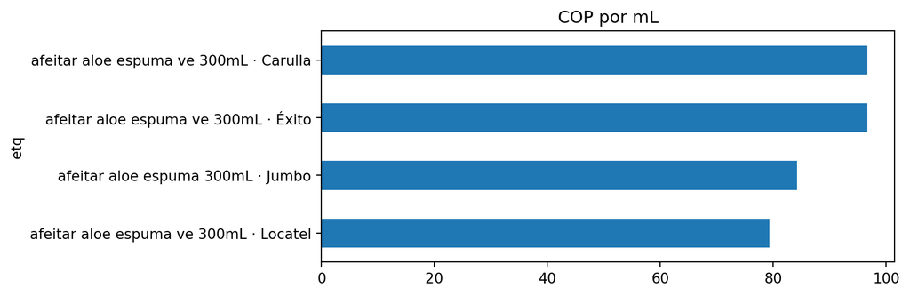

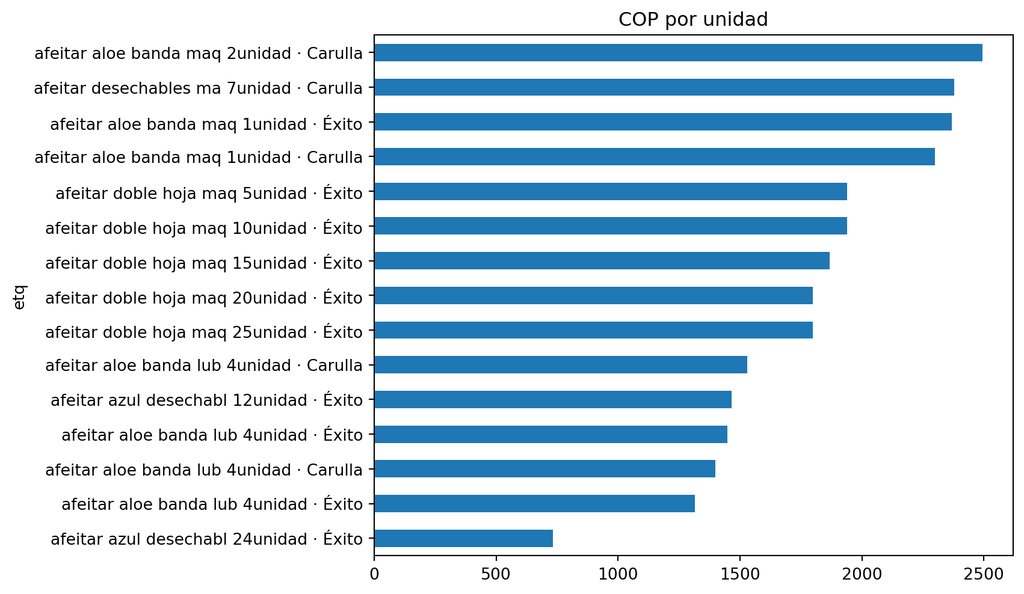

```python
if not P5.empty:
    for u, g in P5.groupby("unidad_base"):
        g = g.sort_values("precio_por_unidad").head(15)   # las 15 presentaciones de menor precio por unidad
        g = g.assign(etq=g.nombre_base.str[:22] + " " + g.contenido_total.astype(int).astype(str) + u + " · " + g.comercio)
        g.sort_values("precio_por_unidad").plot.barh(x="etq", y="precio_por_unidad", legend=False,
                                                     figsize=(9, max(3, .35 * len(g))), title=f"COP por {u}")
        plt.tight_layout(); plt.show()
```

Solo se comparan presentaciones con la misma unidad base; un tamaño mayor exige mayor desembolso, pero puede tener menor precio por unidad.

**Código**

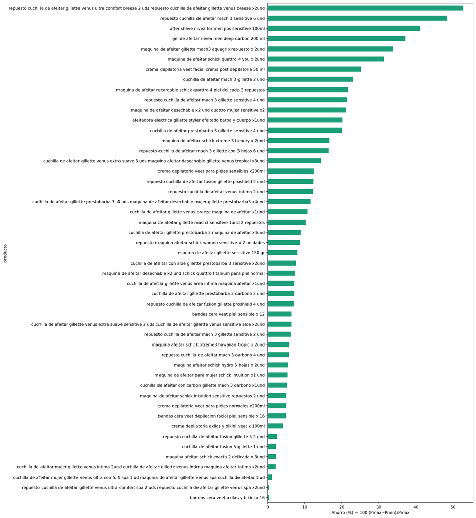

Oportunidad de ahorro (%) al comprar en el comercio más barato

```python
if not P4.empty:
    P4.sort_values("ahorro_pct").plot.barh(x="producto", y="ahorro_pct", legend=False, figsize=(9, max(4, .45 * len(P4))), color="#1b9e77")
    plt.xlabel("Ahorro (%) = 100·(Pmax−Pmin)/Pmax"); plt.tight_layout(); plt.show()
```

# 7. Limitaciones y conclusiones

- **Completitud de Éxito:** su sección «Máquinas de afeitar eléctricas» (~3.600 productos, en su mayoría vendedores externos) supera el tope de 2.500 resultados por consulta de VTEX; se divide por rangos de precio, pero ese filtro no devuelve los productos sin precio (agotados), por lo que `ejecuciones.estado` puede quedar *parcial*. Esos productos no tienen precio y no afectan la comparación.
- **Disponibilidad:** los productos agotados se guardan con precio `NULL`; solo cuentan como comparables los que tienen precio en los tres comercios en la misma ejecución.
- Los precios reflejan un instante y pueden variar con promociones, ciudad o stock; los agotados se excluyen (NULL).
- La correspondencia usa EAN o reglas de texto documentadas; revisar `comparables.csv` antes de entregar.
- **Para el consumidor:** comprar cada presentación en el comercio de la columna `mas_barato` (P3); preferir el tamaño con menor COP/unidad (P5) solo si se consumirá completo, pues exige mayor desembolso inicial.

**Código**

```python
print(interpretar())
```

```
Se compararon 49 presentaciones. La mayor diferencia entre comercios está en «repuesto cuchilla de afeitar gillette venus ultra comfort breeze 2 uds repuesto cuchilla de afeitar gillette venus breeze x2und»: 22,260 COP (52.8%). Ahorro promedio: 13.3%. No se concluye que un comercio sea globalmente m…
```